# Model for ART utilisation over time

Complete case analysis

Oisin Fitzgerald

# Introduction

This document describes the longitudinal modeling of assisted reproductive technology utilisation (ART) as a function of the United Nations produced Human Development Index (HDI) and Gender Inequality Index (GII). Greater details on the rationale for the study can be found in the main manuscript.

Summary of methods and findings:

# Data

There is more detailed description of the data used in the following files:

Several countries are removed from the analysis due to poor data quality (or missing data in the case of Taiwan)

# Index models

We note the following:

## Standard formulation

Model: log ART utilisation = time in years + GII + HDI + random country intercept

```
## R2:  0.7309914 0.9577593
```

Model parameter estimates

| effect | group | term | estimate | std.error | statistic |
| --- | --- | --- | --- | --- | --- |
| fixed | NA | (Intercept) | 5.522 | 0.100 | 55.343 |
| fixed | NA | time | 0.068 | 0.028 | 2.404 |
| fixed | NA | gii_un | -0.615 | 0.183 | -3.364 |
| fixed | NA | hdi_un | 0.960 | 0.189 | 5.071 |
| ran_pars | country | sd__(Intercept) | 0.776 | NA | NA |
| ran_pars | Residual | sd__Observation | 0.335 | NA | NA |

Model fit statistics

| sigma | logLik | AIC | BIC | REMLcrit | df.residual |
| --- | --- | --- | --- | --- | --- |
| 0.335 | -228.657 | 469.313 | 492.304 | 457.313 | 335 |

Model 95% intervals

|  | 2.5 % | 97.5 % |
| --- | --- | --- |
| .sig01 | 0.639 | 0.917 |
| .sigma | 0.308 | 0.365 |
| (Intercept) | 5.327 | 5.716 |
| time | 0.013 | 0.123 |
| gii_un | -0.980 | -0.252 |
| hdi_un | 0.583 | 1.337 |

On the exp scale:

Model parameter estimates

[output not shown]

Model 95% intervals

[output not shown]

Plot on the exp scale:

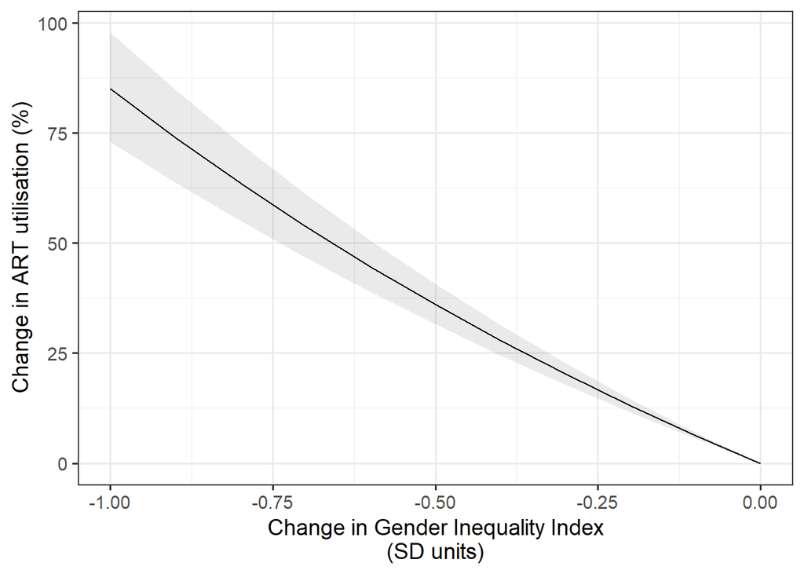

| change_gii_un | change_art | change_art_lower | change_art_upper |
| --- | --- | --- | --- |
| 0.0 | 1.000000 | 1.000000 | 1.000000 |
| -0.1 | 1.063464 | 1.070606 | 1.056371 |
| -0.2 | 1.130956 | 1.146196 | 1.115919 |
| -0.3 | 1.202731 | 1.227124 | 1.178823 |
| -0.4 | 1.279062 | 1.313766 | 1.245274 |
| -0.5 | 1.360236 | 1.406525 | 1.315471 |
| -0.6 | 1.446562 | 1.505833 | 1.389625 |
| -0.7 | 1.538367 | 1.612154 | 1.467958 |
| -0.8 | 1.635999 | 1.725980 | 1.550708 |
| -0.9 | 1.739826 | 1.847844 | 1.638122 |
| -1.0 | 1.850243 | 1.978312 | 1.730464 |

The quantile-quantile plot for the model appears reasonable.

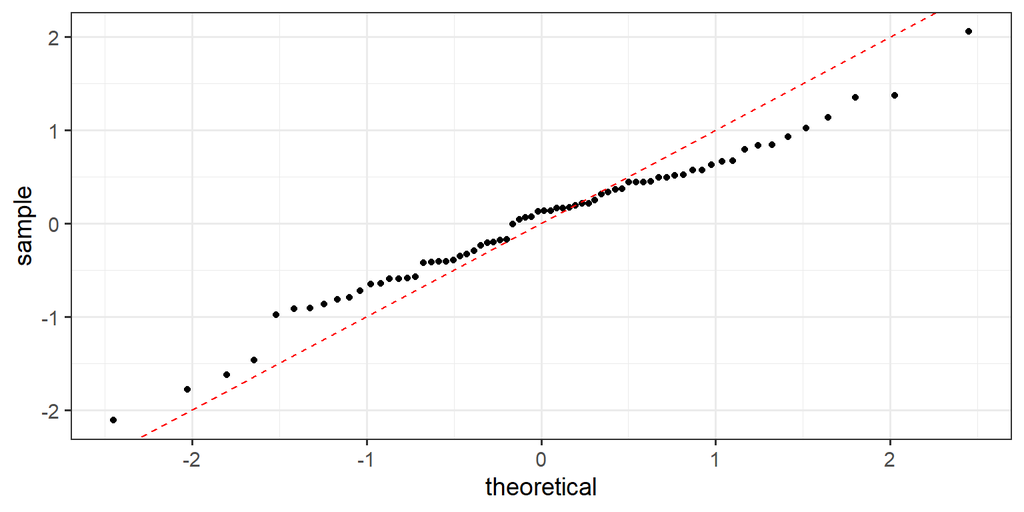

There is evidence of outliers or poor model fit for a couple of south/central American countries.

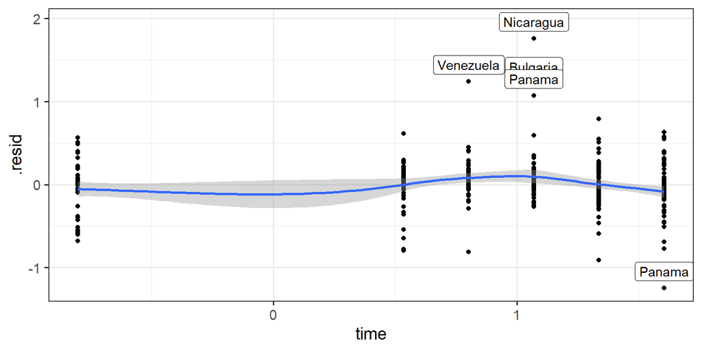

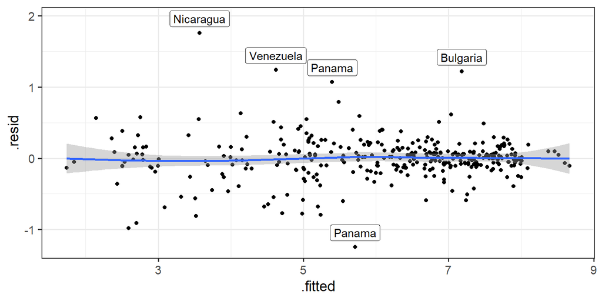

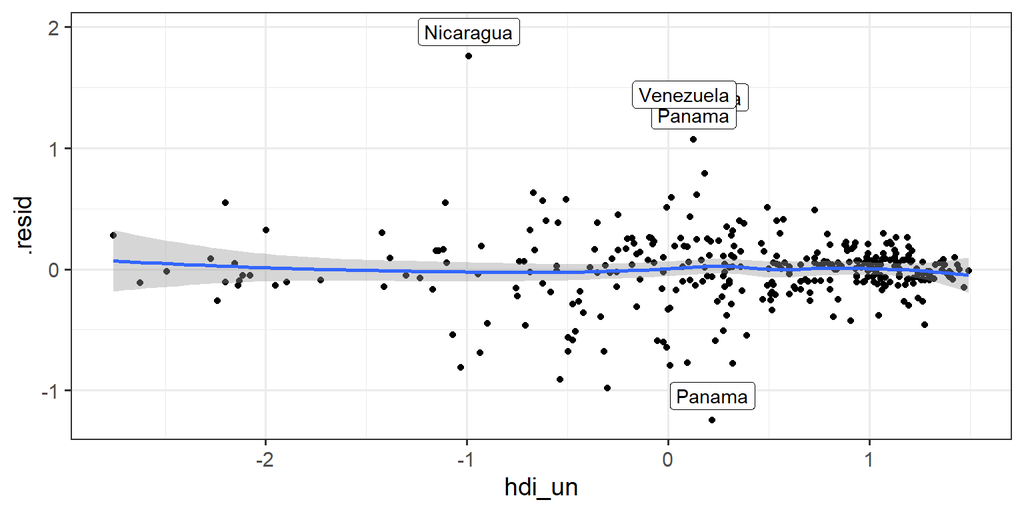

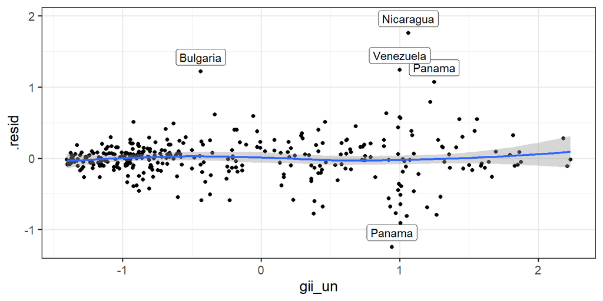

Influence

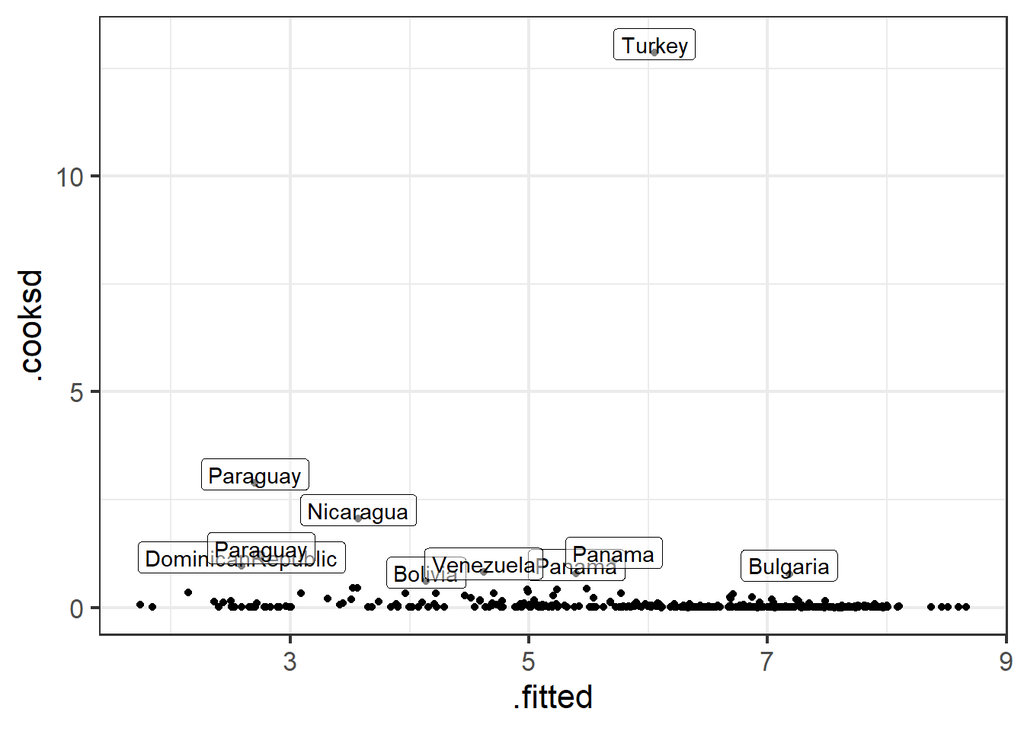

## Standard formulation - each index individually (unadjusted)

Model: log ART utilisation = time in years + GII + random country intercept

[output not shown]

Model parameter estimates

[output not shown]

Model fit statistics

[output not shown]

Model 95% intervals

[output not shown]

Model: log ART utilisation = time in years + HDI + random country intercept

```
## R2:  0.6700893 0.9564836
```

Model parameter estimates

| effect | group | term | estimate | std.error | statistic |
| --- | --- | --- | --- | --- | --- |
| fixed | NA | (Intercept) | 5.445 | 0.104 | 52.226 |
| fixed | NA | time | 0.116 | 0.018 | 6.507 |
| fixed | NA | hdi_un | 1.613 | 0.096 | 16.777 |
| ran_pars | country | sd__(Intercept) | 0.879 | NA | NA |
| ran_pars | Residual | sd__Observation | 0.343 | NA | NA |

Model fit statistics

| sigma | logLik | AIC | BIC | REMLcrit | df.residual |
| --- | --- | --- | --- | --- | --- |
| 0.343 | -391.136 | 792.272 | 814.956 | 782.272 | 685 |

Model 95% intervals

|  | 2.5 % | 97.5 % |
| --- | --- | --- |
| .sig01 | 0.738 | 1.036 |
| .sigma | 0.324 | 0.362 |
| (Intercept) | 5.240 | 5.649 |
| time | 0.081 | 0.151 |
| hdi_un | 1.424 | 1.806 |

## Decomposition formulation

This model decompose effects effects into within country and between country effects. effects. The resulting between and within coefficients can be compared to assess whether it is reasonable to assume that the between and within country effects are similar, which can be used to reason about causation of the effect etc. We originally decomposed time as it is measured unevenly between countries (due to missing outcome data) and this is recommended in the literature, however it results in non-identifiability.

```
## R2:  0.7580163 0.9587298
```

Model parameter estimates

| effect | group | term | estimate | std.error | statistic |
| --- | --- | --- | --- | --- | --- |
| fixed | NA | (Intercept) | 5.441 | 0.099 | 54.993 |
| fixed | NA | time | 0.054 | 0.066 | 0.819 |
| fixed | NA | gii_d | 0.117 | 0.329 | 0.354 |
| fixed | NA | gii_m | -1.063 | 0.221 | -4.809 |
| fixed | NA | hdi_d | 1.730 | 0.468 | 3.695 |
| fixed | NA | hdi_m | 0.560 | 0.217 | 2.576 |
| ran_pars | country | sd__(Intercept) | 0.736 | NA | NA |
| ran_pars | Residual | sd__Observation | 0.334 | NA | NA |

Model fit statistics

| sigma | logLik | AIC | BIC | REMLcrit | df.residual |
| --- | --- | --- | --- | --- | --- |
| 0.334 | -223.365 | 462.731 | 493.386 | 446.731 | 333 |

Model 95% intervals

|  | 2.5 % | 97.5 % |
| --- | --- | --- |
| .sig01 | 0.605 | 0.866 |
| .sigma | 0.306 | 0.362 |
| (Intercept) | 5.249 | 5.633 |
| time | -0.074 | 0.187 |
| gii_d | -0.522 | 0.781 |
| gii_m | -1.492 | -0.633 |
| hdi_d | 0.809 | 2.641 |
| hdi_m | 0.138 | 0.982 |

As before, the quantile-quantile plot for the model appears reasonable.

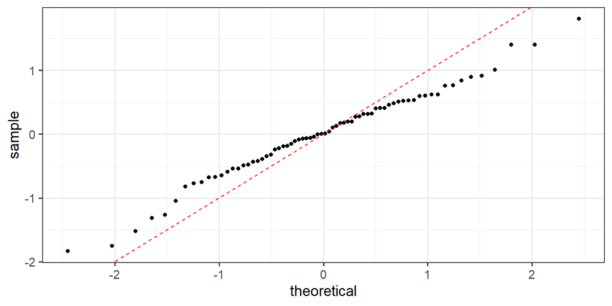

As before, there is evidence of outliers or poor model fit for a couple of south/central American countries.

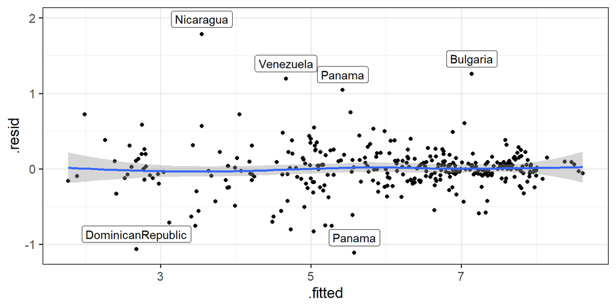

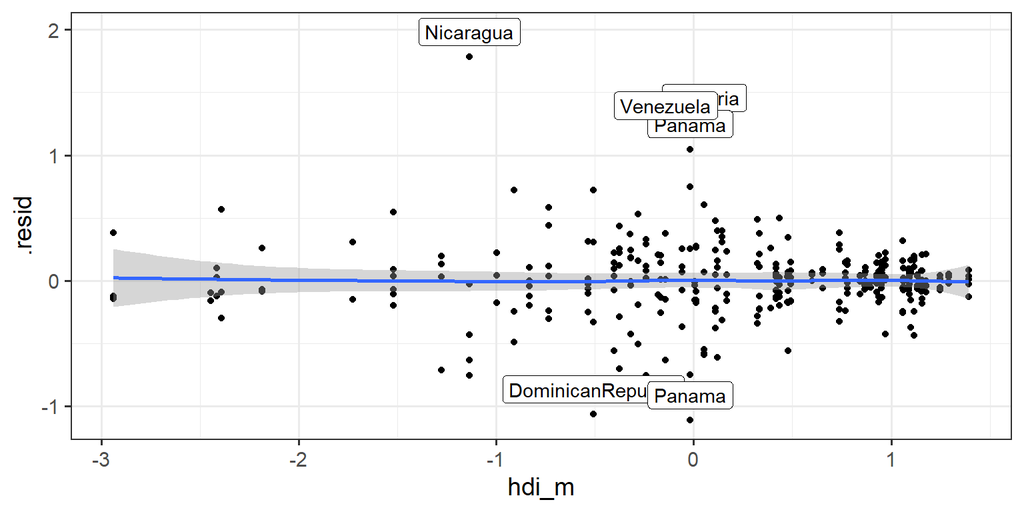

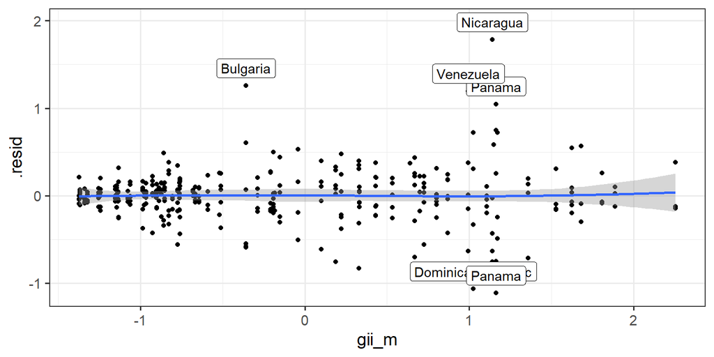

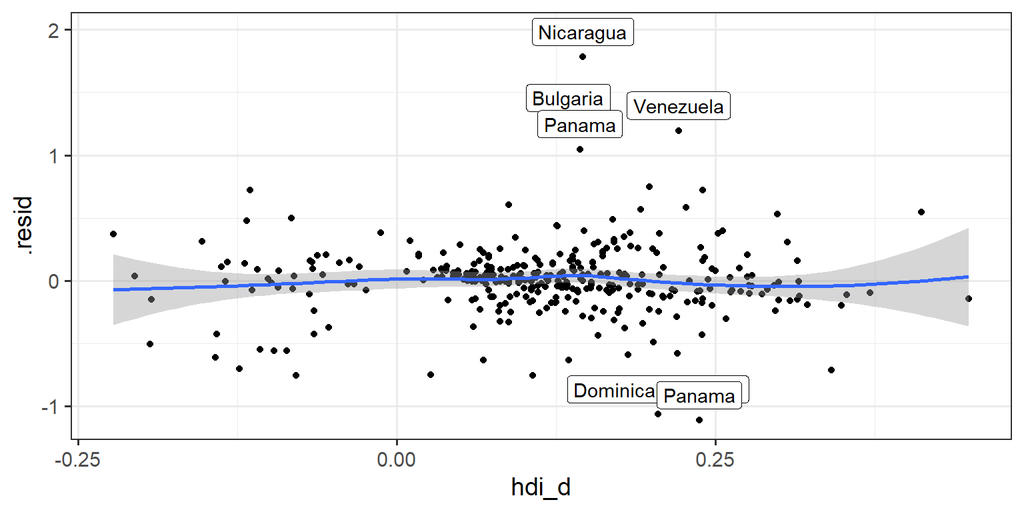

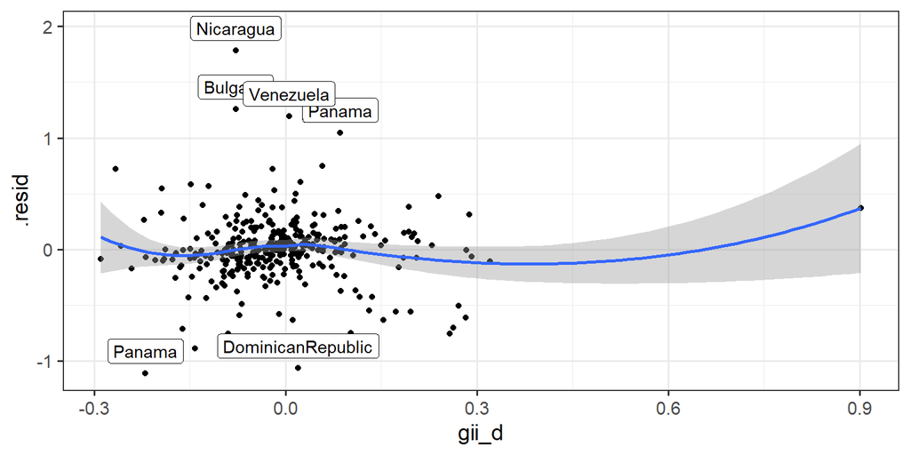

Influence

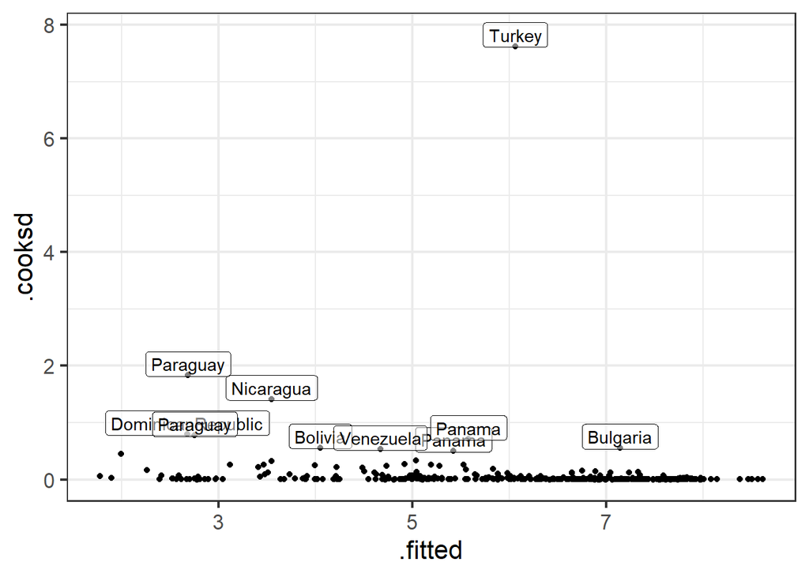

GII only

```
## R2:  0.7540942 0.957544
```

Model parameter estimates

| effect | group | term | estimate | std.error | statistic |
| --- | --- | --- | --- | --- | --- |
| fixed | NA | (Intercept) | 5.500 | 0.100 | 55.187 |
| fixed | NA | time | 0.239 | 0.045 | 5.281 |
| fixed | NA | gii_d | -0.086 | 0.331 | -0.258 |
| fixed | NA | gii_m | -1.529 | 0.092 | -16.558 |
| ran_pars | country | sd__(Intercept) | 0.750 | NA | NA |
| ran_pars | Residual | sd__Observation | 0.342 | NA | NA |

Model fit statistics

| sigma | logLik | AIC | BIC | REMLcrit | df.residual |
| --- | --- | --- | --- | --- | --- |
| 0.342 | -232.036 | 476.071 | 499.062 | 464.071 | 335 |

Model 95% intervals

|  | 2.5 % | 97.5 % |
| --- | --- | --- |
| .sig01 | 0.621 | 0.889 |
| .sigma | 0.314 | 0.372 |
| (Intercept) | 5.305 | 5.695 |
| time | 0.151 | 0.329 |
| gii_d | -0.734 | 0.583 |
| gii_m | -1.710 | -1.348 |

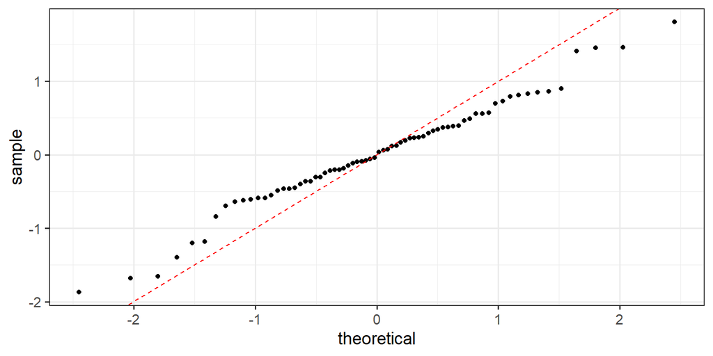

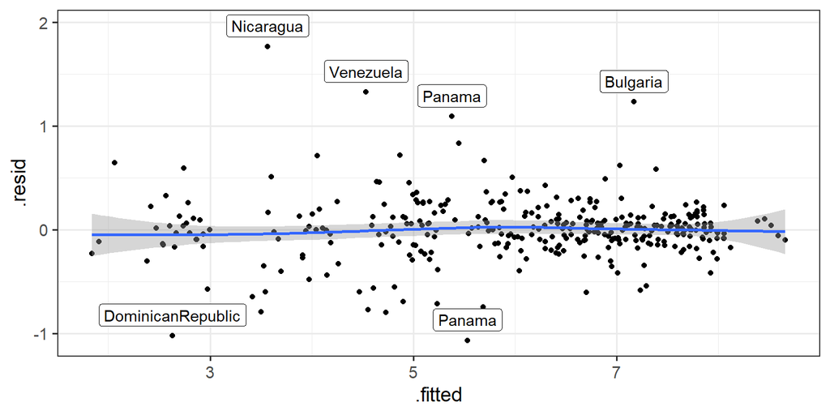

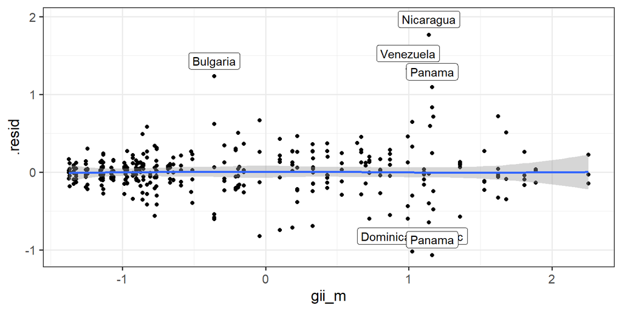

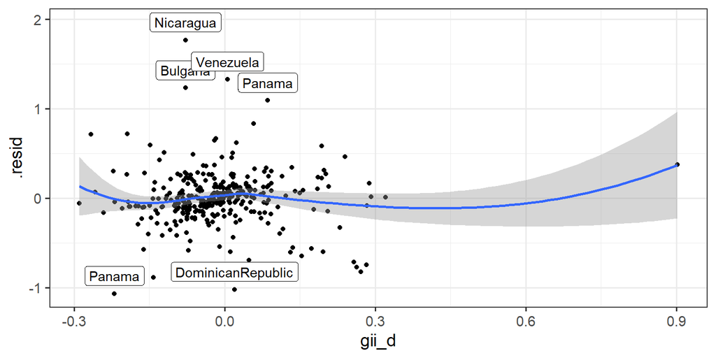

Influence

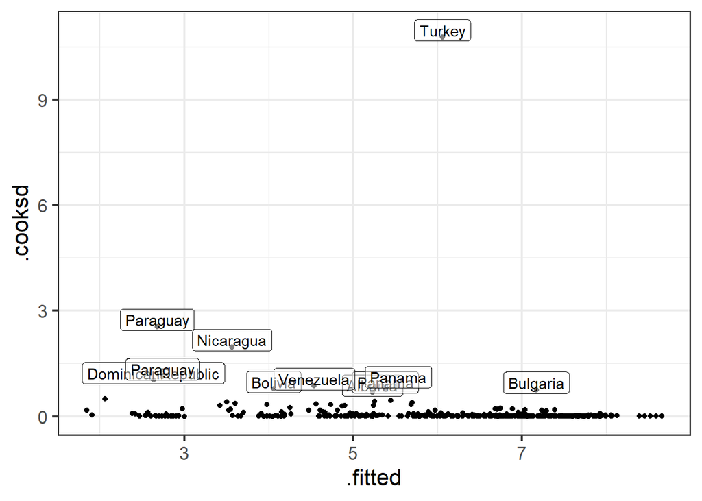

**This table appears in paper supplements**

# Component models

HDI * Life expectancy * Expected years of schooling * Mean years of schooling * GNI per capita

GII * Maternal mortality ratio * Adolescent birth rate  
* Female/male population with at least secondary education * Female/male share of parliamentary seats  
* Female/male labour force participation

## Correlation

Strong correlations between the components.

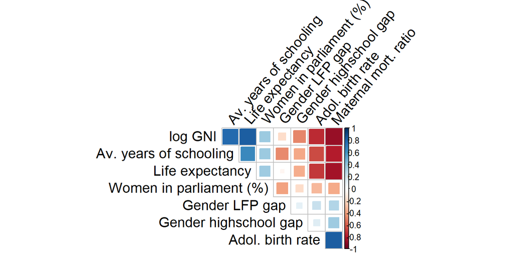

Poorly condition matrix.

```
## max/min eigenval of XtX: 1891249
```

The cumulative sum of the eigenvalues of the correlation matrix dividing by their sum.

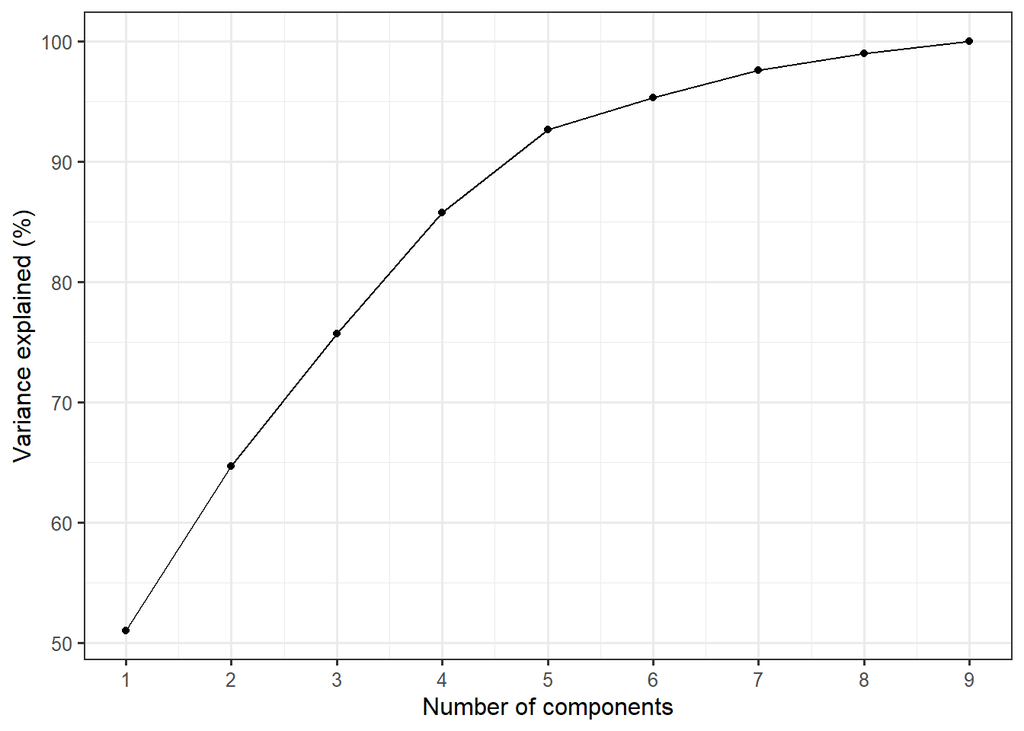

## Standard formulation - no shrinkage on fixed effects

This standard LMM model is overly influence by multicollinearity, fitted below for reference.

```
## R2:  0.7735406 0.958291
```

Model parameter estimates

| effect | group | term | estimate | std.error | statistic |
| --- | --- | --- | --- | --- | --- |
| fixed | NA | (Intercept) | -2.088 | 2.814 | -0.742 |
| fixed | NA | time | 0.044 | 0.039 | 1.112 |
| fixed | NA | ln_adol_birth_rate_wb | -0.081 | 0.160 | -0.505 |
| fixed | NA | ln_maternal_mortality_wb | -0.311 | 0.144 | -2.163 |
| fixed | NA | women_parl_wb | 0.378 | 0.530 | 0.713 |
| fixed | NA | school_gap | 1.654 | 1.237 | 1.337 |
| fixed | NA | labour_gap_wb | -1.093 | 1.020 | -1.071 |
| fixed | NA | mean_sch_un | 0.095 | 0.060 | 1.593 |
| fixed | NA | life_expect_wb | 0.010 | 0.033 | 0.314 |
| fixed | NA | ln_gni_wb | 0.767 | 0.236 | 3.248 |
| ran_pars | country | sd__(Intercept) | 0.703 | NA | NA |
| ran_pars | Residual | sd__Observation | 0.334 | NA | NA |

Model 95% intervals

|  | 2.5 % | 97.5 % |
| --- | --- | --- |
| .sig01 | 0.582 | 0.866 |
| .sigma | 0.306 | 0.367 |
| (Intercept) | -7.836 | 3.457 |
| time | -0.034 | 0.121 |
| ln_adol_birth_rate_wb | -0.395 | 0.244 |
| ln_maternal_mortality_wb | -0.594 | -0.024 |
| women_parl_wb | -0.669 | 1.430 |
| school_gap | -0.806 | 4.099 |
| labour_gap_wb | -3.099 | 0.944 |
| mean_sch_un | -0.023 | 0.214 |
| life_expect_wb | -0.055 | 0.075 |
| ln_gni_wb | 0.300 | 1.247 |

Model fit statistics

| sigma | logLik | AIC | BIC | deviance | df.residual |
| --- | --- | --- | --- | --- | --- |
| 0.334 | -195.276 | 414.552 | 459.274 | 390.552 | 295 |

## Standard formulation - L2 shrinkage on fixed effects

In order to deal with the collinearity we apply $L2$ shrinkage to the fixed effects (as is already done to the random effects). We scale the data so the covariates are zero mean and standard deviation one. We also mean centre the outcome to remove the need for an intercept term.

Firstly, we refit the unpenalised model to the scaled data.

```
## R2:  0.7097716 0.9596885
```

Model parameter estimates

| effect | group | term | estimate | std.error | statistic |
| --- | --- | --- | --- | --- | --- |
| fixed | NA | time1 | 0.035 | 0.041 | 0.841 |
| fixed | NA | ln_adol_birth_rate_wb1 | -0.167 | 0.172 | -0.969 |
| fixed | NA | ln_maternal_mortality_wb1 | -0.492 | 0.236 | -2.085 |
| fixed | NA | women_parl_wb1 | 0.054 | 0.059 | 0.912 |
| fixed | NA | school_gap1 | 0.045 | 0.089 | 0.510 |
| fixed | NA | labour_gap_wb1 | 0.065 | 0.142 | 0.458 |
| fixed | NA | mean_sch_un1 | 0.244 | 0.178 | 1.373 |
| fixed | NA | life_expect_wb1 | -0.319 | 0.259 | -1.231 |
| fixed | NA | ln_gni_wb1 | 0.943 | 0.240 | 3.932 |
| ran_pars | country | sd__(Intercept) | 0.829 | NA | NA |
| ran_pars | Residual | sd__Observation | 0.333 | NA | NA |

Model 95% intervals

|  | 2.5 % | 97.5 % |
| --- | --- | --- |
| .sig01 | 0.688 | 1.019 |
| .sigma | 0.305 | 0.366 |
| time1 | -0.047 | 0.116 |
| ln_adol_birth_rate_wb1 | -0.509 | 0.191 |
| ln_maternal_mortality_wb1 | -0.955 | -0.017 |
| women_parl_wb1 | -0.063 | 0.170 |
| school_gap1 | -0.129 | 0.220 |
| labour_gap_wb1 | -0.216 | 0.345 |
| mean_sch_un1 | -0.106 | 0.596 |
| life_expect_wb1 | -0.828 | 0.205 |
| ln_gni_wb1 | 0.471 | 1.423 |

Model fit statistics

| sigma | logLik | AIC | BIC | deviance | df.residual |
| --- | --- | --- | --- | --- | --- |
| 0.333 | -204.588 | 431.176 | 472.172 | 409.176 | 296 |

Fitting the model over various size of $\lambda$ in the $L2$ penalty $\lambda\| \beta \|^2$ gives the results shown in the graph below. A $\lambda$ corresponding to an effective number of parameters of 5 appears a reasonable choice in stabilising the coefficient values.

The relationship between the penalty and effective degrees of freedom.

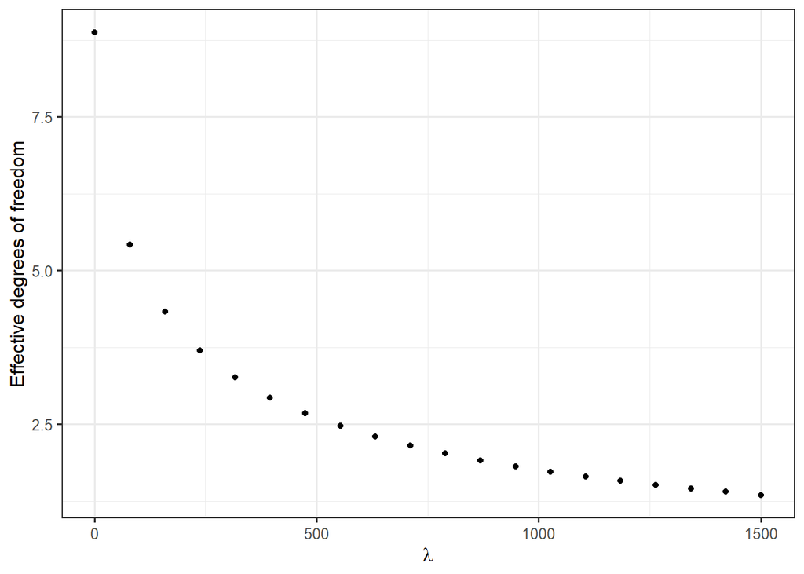

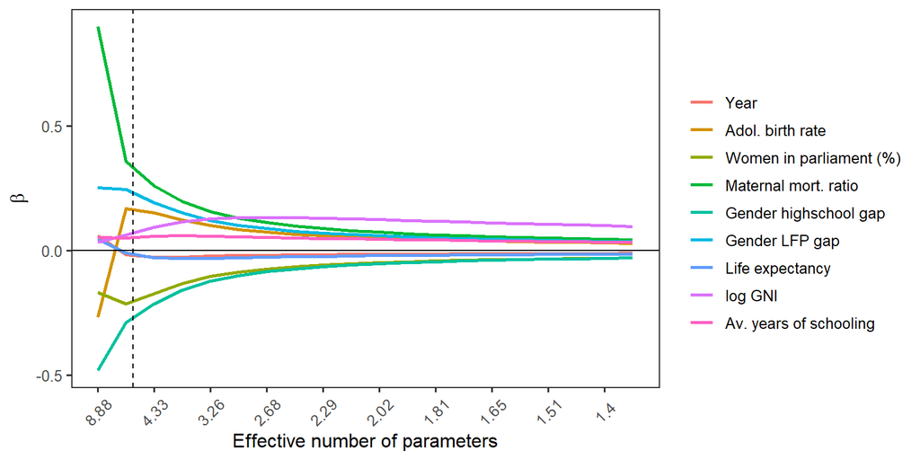

Then we refit the penalised model.

**These results are for the component sensitivity analysis (full cases) model**

Model 95% intervals

|  | beta | se | lower | upper |
| --- | --- | --- | --- | --- |
| time1 | 0.062 | 0.043 | -0.024 | 0.148 |
| ln_adol_birth_rate_wb1 | -0.215 | 0.181 | -0.577 | 0.148 |
| women_parl_wb1 | 0.050 | 0.060 | -0.071 | 0.170 |
| ln_maternal_mortality_wb1 | -0.293 | 0.248 | -0.788 | 0.202 |
| school_gap1 | -0.007 | 0.091 | -0.189 | 0.175 |
| labour_gap_wb1 | -0.016 | 0.149 | -0.314 | 0.282 |
| life_expect_wb1 | 0.167 | 0.273 | -0.378 | 0.713 |
| ln_gni_wb1 | 0.367 | 0.250 | -0.133 | 0.867 |
| mean_sch_un1 | 0.247 | 0.186 | -0.125 | 0.620 |

The marginal R^2

```
## [1] 0.4939551
```

## Model for each component

### Adol Birth Rate

```
## R2:  0.08675416 0.9424139
```

Model parameter estimates

| effect | group | term | estimate | std.error | statistic |
| --- | --- | --- | --- | --- | --- |
| fixed | NA | (Intercept) | -0.476 | 0.168 | -2.826 |
| fixed | NA | time1 | 0.276 | 0.019 | 14.237 |
| fixed | NA | ln_adol_birth_rate_wb1 | -0.386 | 0.123 | -3.139 |
| ran_pars | country | sd__(Intercept) | 1.440 | NA | NA |
| ran_pars | Residual | sd__Observation | 0.373 | NA | NA |

Model 95% intervals

|  | 2.5 % | 97.5 % |
| --- | --- | --- |
| .sig01 | 1.073 | 1.973 |
| .sigma | 0.351 | 0.399 |
| (Intercept) | -0.829 | -0.136 |
| time1 | 0.222 | 0.336 |
| ln_adol_birth_rate_wb1 | -0.812 | 0.119 |

Model fit statistics

| sigma | logLik | AIC | BIC | deviance | df.residual |
| --- | --- | --- | --- | --- | --- |
| 0.373 | -479.088 | 968.176 | 990.889 | 958.176 | 689 |

### ln_maternal_mortality_wb

```
## R2:  0.6351255 0.9417569
```

Model parameter estimates

| effect | group | term | estimate | std.error | statistic |
| --- | --- | --- | --- | --- | --- |
| fixed | NA | (Intercept) | -0.517 | 0.099 | -5.234 |
| fixed | NA | time1 | 0.234 | 0.015 | 15.142 |
| fixed | NA | ln_maternal_mortality_wb1 | -1.365 | 0.087 | -15.764 |
| ran_pars | country | sd__(Intercept) | 0.837 | NA | NA |
| ran_pars | Residual | sd__Observation | 0.365 | NA | NA |

Model 95% intervals

|  | 2.5 % | 97.5 % |
| --- | --- | --- |
| .sig01 | 0.711 | 1.002 |
| .sigma | 0.345 | 0.386 |
| (Intercept) | -0.714 | -0.321 |
| time1 | 0.203 | 0.264 |
| ln_maternal_mortality_wb1 | -1.536 | -1.185 |

Model fit statistics

| sigma | logLik | AIC | BIC | deviance | df.residual |
| --- | --- | --- | --- | --- | --- |
| 0.365 | -424.912 | 859.824 | 882.537 | 849.824 | 689 |

### women_parl_wb

```
## R2:  0.03457079 0.9597223
```

Model parameter estimates

| effect | group | term | estimate | std.error | statistic |
| --- | --- | --- | --- | --- | --- |
| fixed | NA | (Intercept) | -0.506 | 0.201 | -2.516 |
| fixed | NA | time1 | 0.281 | 0.018 | 16.076 |
| fixed | NA | women_parl_wb1 | 0.138 | 0.046 | 3.015 |
| ran_pars | country | sd__(Intercept) | 1.721 | NA | NA |
| ran_pars | Residual | sd__Observation | 0.359 | NA | NA |

Model 95% intervals

|  | 2.5 % | 97.5 % |
| --- | --- | --- |
| .sig01 | 1.474 | 2.044 |
| .sigma | 0.340 | 0.380 |
| (Intercept) | -0.905 | -0.107 |
| time1 | 0.247 | 0.316 |
| women_parl_wb1 | 0.048 | 0.229 |

Model fit statistics

| sigma | logLik | AIC | BIC | deviance | df.residual |
| --- | --- | --- | --- | --- | --- |
| 0.359 | -464.186 | 938.373 | 961.027 | 928.373 | 681 |

### school_gap

```
## R2:  0.01384096 0.9607977
```

Model parameter estimates

| effect | group | term | estimate | std.error | statistic |
| --- | --- | --- | --- | --- | --- |
| fixed | NA | (Intercept) | -0.381 | 0.203 | -1.877 |
| fixed | NA | time1 | 0.246 | 0.027 | 9.115 |
| fixed | NA | school_gap1 | -0.116 | 0.089 | -1.301 |
| ran_pars | country | sd__(Intercept) | 1.679 | NA | NA |
| ran_pars | Residual | sd__Observation | 0.342 | NA | NA |

Model 95% intervals

|  | 2.5 % | 97.5 % |
| --- | --- | --- |
| .sig01 | 1.430 | 2.005 |
| .sigma | 0.315 | 0.372 |
| (Intercept) | -0.785 | 0.022 |
| time1 | 0.193 | 0.299 |
| school_gap1 | -0.293 | 0.060 |

Model fit statistics

| sigma | logLik | AIC | BIC | deviance | df.residual |
| --- | --- | --- | --- | --- | --- |
| 0.342 | -284.02 | 578.04 | 597.243 | 568.04 | 339 |

### labour_gap_wb

```
## R2:  0.0718291 0.9713753
```

Model parameter estimates

| effect | group | term | estimate | std.error | statistic |
| --- | --- | --- | --- | --- | --- |
| fixed | NA | (Intercept) | -0.315 | 0.250 | -1.260 |
| fixed | NA | time1 | 0.372 | 0.019 | 19.699 |
| fixed | NA | labour_gap_wb1 | 0.644 | 0.136 | 4.721 |
| ran_pars | country | sd__(Intercept) | 1.998 | NA | NA |
| ran_pars | Residual | sd__Observation | 0.356 | NA | NA |

Model 95% intervals

|  | 2.5 % | 97.5 % |
| --- | --- | --- |
| .sig01 | 1.676 | 2.424 |
| .sigma | 0.336 | 0.379 |
| (Intercept) | -0.811 | 0.187 |
| time1 | 0.333 | 0.410 |
| labour_gap_wb1 | 0.357 | 0.930 |

Model fit statistics

| sigma | logLik | AIC | BIC | deviance | df.residual |
| --- | --- | --- | --- | --- | --- |
| 0.356 | -421.877 | 853.753 | 875.91 | 843.753 | 616 |

### mean_sch_un

```
## R2:  0.2056347 0.9341726
```

Model parameter estimates

| effect | group | term | estimate | std.error | statistic |
| --- | --- | --- | --- | --- | --- |
| fixed | NA | (Intercept) | -0.510 | 0.146 | -3.504 |
| fixed | NA | time1 | 0.214 | 0.021 | 10.190 |
| fixed | NA | mean_sch_un1 | 0.710 | 0.109 | 6.483 |
| ran_pars | country | sd__(Intercept) | 1.232 | NA | NA |
| ran_pars | Residual | sd__Observation | 0.370 | NA | NA |

Model 95% intervals

|  | 2.5 % | 97.5 % |
| --- | --- | --- |
| .sig01 | 1.010 | 1.538 |
| .sigma | 0.350 | 0.393 |
| (Intercept) | -0.799 | -0.215 |
| time1 | 0.166 | 0.263 |
| mean_sch_un1 | 0.413 | 0.973 |

Model fit statistics

| sigma | logLik | AIC | BIC | deviance | df.residual |
| --- | --- | --- | --- | --- | --- |
| 0.37 | -459.241 | 928.482 | 951.165 | 918.482 | 685 |

### life_expect_wb

```
## R2:  0.3516716 0.9426503
```

Model parameter estimates

| effect | group | term | estimate | std.error | statistic |
| --- | --- | --- | --- | --- | --- |
| fixed | NA | (Intercept) | -0.526 | 0.137 | -3.831 |
| fixed | NA | time1 | 0.166 | 0.021 | 7.894 |
| fixed | NA | life_expect_wb1 | 1.170 | 0.121 | 9.688 |
| ran_pars | country | sd__(Intercept) | 1.171 | NA | NA |
| ran_pars | Residual | sd__Observation | 0.365 | NA | NA |

Model 95% intervals

|  | 2.5 % | 97.5 % |
| --- | --- | --- |
| .sig01 | 1.000 | 1.397 |
| .sigma | 0.345 | 0.386 |
| (Intercept) | -0.799 | -0.253 |
| time1 | 0.125 | 0.209 |
| life_expect_wb1 | 0.923 | 1.408 |

Model fit statistics

| sigma | logLik | AIC | BIC | deviance | df.residual |
| --- | --- | --- | --- | --- | --- |
| 0.365 | -449.567 | 909.134 | 931.847 | 899.134 | 689 |

### ln_gni_wb

```
## R2:  0.6373234 0.9562044
```

Model parameter estimates

| effect | group | term | estimate | std.error | statistic |
| --- | --- | --- | --- | --- | --- |
| fixed | NA | (Intercept) | -0.476 | 0.107 | -4.447 |
| fixed | NA | time1 | 0.048 | 0.020 | 2.330 |
| fixed | NA | ln_gni_wb1 | 1.535 | 0.088 | 17.424 |
| ran_pars | country | sd__(Intercept) | 0.910 | NA | NA |
| ran_pars | Residual | sd__Observation | 0.337 | NA | NA |

Model 95% intervals

|  | 2.5 % | 97.5 % |
| --- | --- | --- |
| .sig01 | 0.778 | 1.082 |
| .sigma | 0.319 | 0.357 |
| (Intercept) | -0.688 | -0.263 |
| time1 | 0.007 | 0.088 |
| ln_gni_wb1 | 1.362 | 1.709 |

Model fit statistics

| sigma | logLik | AIC | BIC | deviance | df.residual |
| --- | --- | --- | --- | --- | --- |
| 0.337 | -381.282 | 772.565 | 795.263 | 762.565 | 687 |

# Appendix A: additional models

## Standard formulation with excluded countries

A better model with the excluded countries included adds a Middle East/North Africa indicator variable. Note that due to the high variability of (within country) ART rates in the excluded countries these results may not be reliable.

Model: log ART utilisation = time in years + GII + HDI + Middle East/North Africa + random country intercept

```
## R2:  0.7281724 0.9534959
```

Model parameter estimates

| effect | group | term | estimate | std.error | statistic |
| --- | --- | --- | --- | --- | --- |
| fixed | NA | (Intercept) | 5.513 | 0.099 | 55.505 |
| fixed | NA | time | 0.065 | 0.029 | 2.244 |
| fixed | NA | gii_un | -0.519 | 0.171 | -3.037 |
| fixed | NA | hdi_un | 1.058 | 0.178 | 5.944 |
| fixed | NA | me_na | 2.324 | 0.396 | 5.866 |
| ran_pars | country | sd__(Intercept) | 0.770 | NA | NA |
| ran_pars | Residual | sd__Observation | 0.350 | NA | NA |

Model fit statistics

| sigma | logLik | AIC | BIC | REMLcrit | df.residual |
| --- | --- | --- | --- | --- | --- |
| 0.35 | -250.282 | 514.564 | 541.63 | 500.564 | 346 |

## Decomposition formulation with excluded countries

Note that due to the high variability of (within country) ART rates in the excluded countries these results may not be reliable.

```
## R2:  0.7520736 0.9545321
```

Model parameter estimates

| effect | group | term | estimate | std.error | statistic |
| --- | --- | --- | --- | --- | --- |
| fixed | NA | (Intercept) | 5.427 | 0.099 | 54.849 |
| fixed | NA | time | 0.034 | 0.068 | 0.505 |
| fixed | NA | gii_d | 0.247 | 0.327 | 0.755 |
| fixed | NA | gii_m | -0.948 | 0.207 | -4.575 |
| fixed | NA | hdi_d | 1.986 | 0.480 | 4.139 |
| fixed | NA | hdi_m | 0.675 | 0.205 | 3.296 |
| fixed | NA | me_na | 2.484 | 0.382 | 6.503 |
| ran_pars | country | sd__(Intercept) | 0.734 | NA | NA |
| ran_pars | Residual | sd__Observation | 0.348 | NA | NA |

Model fit statistics

| sigma | logLik | AIC | BIC | REMLcrit | df.residual |
| --- | --- | --- | --- | --- | --- |
| 0.348 | -244.392 | 506.785 | 541.583 | 488.785 | 344 |

## Standard formulation with Turkey excluded

Turkey was an influential outlier above - effect of removing.

```
## R2:  0.7623631 0.9576568
```

Model parameter estimates

| effect | group | term | estimate | std.error | statistic |
| --- | --- | --- | --- | --- | --- |
| fixed | NA | (Intercept) | 5.498 | 0.094 | 58.579 |
| fixed | NA | time | 0.070 | 0.028 | 2.509 |
| fixed | NA | gii_un | -0.765 | 0.179 | -4.283 |
| fixed | NA | hdi_un | 0.840 | 0.183 | 4.602 |
| ran_pars | country | sd__(Intercept) | 0.720 | NA | NA |
| ran_pars | Residual | sd__Observation | 0.335 | NA | NA |

Model fit statistics

| sigma | logLik | AIC | BIC | REMLcrit | df.residual |
| --- | --- | --- | --- | --- | --- |
| 0.335 | -223.13 | 458.26 | 481.234 | 446.26 | 334 |

## Decomposition formulation with Turkey excluded

Turkey was an influential outlier above - effect of removing.

```
## R2:  0.7759529 0.9591427
```

Model parameter estimates

| effect | group | term | estimate | std.error | statistic |
| --- | --- | --- | --- | --- | --- |
| fixed | NA | (Intercept) | 5.428 | 0.096 | 56.820 |
| fixed | NA | time | 0.024 | 0.067 | 0.354 |
| fixed | NA | gii_d | -0.154 | 0.342 | -0.452 |
| fixed | NA | gii_m | -1.123 | 0.213 | -5.275 |
| fixed | NA | hdi_d | 1.774 | 0.466 | 3.805 |
| fixed | NA | hdi_m | 0.522 | 0.209 | 2.498 |
| ran_pars | country | sd__(Intercept) | 0.704 | NA | NA |
| ran_pars | Residual | sd__Observation | 0.333 | NA | NA |

Model fit statistics

| sigma | logLik | AIC | BIC | REMLcrit | df.residual |
| --- | --- | --- | --- | --- | --- |
| 0.333 | -218.398 | 452.797 | 483.428 | 436.797 | 332 |